# Multinomial Regression using Hyperparameter Optimization with SVM

Niharika Sharma

September 19, 2019

## Defining data

Certain columns have been deleted due to redundancy issues. The List of the deleted columns: PriceCH PriceMM Store7 ListPriceDiff STORE

More crucial attribute than the prices of both these brands is the price difference between both these brands. We already have the Store ID in the dataset so STORE and Store7 need not be included in the dataset. List Price difference is a redundant attribute as we already have the Sales Price Difference in the data.

Removing such redundant variables in the dataset and keeping more relevant attributes will help us avoid the overfitting of the model.

Creating a Partition for the train and test datasets.

```r
juice <- read_csv("juice.csv")
drops <- c("PriceCH", "PriceMM" ,"Store7", "ListPriceDiff", "STORE")
juice <- select(juice,-drops)

juice$Purchase <- as.factor(juice$Purchase)

set.seed(123)
train.index <- createDataPartition(juice$Purchase , p=0.8, list=FALSE)
juice_train <- juice[train.index,]
juice_test <- juice[-train.index,]
```

## Linear SVM Model

```r
set.seed(123)
svm_lnr <- svm(Purchase~., data=juice_train, kernel="linear", cost=0.01)
summary(svm_lnr)
```

```
##
## Call:
## svm(formula = Purchase ~ ., data = juice_train, kernel = "linear",
##     cost = 0.01)
##
##
## Parameters:
##    SVM-Type:  C-classification
##  SVM-Kernel:  linear
##        cost:  0.01
##
## Number of Support Vectors:  449
##
##  ( 225 224 )
##
##
## Number of Classes:  2
##
## Levels:
##  CH MM
```

```r
pred_lnr1 <- predict( svm_lnr, juice_train)
pred_lnr2 <- predict( svm_lnr, juice_test)

confmatrix_lnr1 <- table(Actual = juice_train$Purchase, Predicted = pred_lnr1)
confmatrix_lnr1
```

```
##       Predicted
## Actual  CH  MM
##     CH 432  56
##     MM  85 227
```

```r
confmatrix_lnr2 <- table(Actual = juice_test$Purchase, Predicted = pred_lnr2)
confmatrix_lnr2
```

```
##       Predicted
## Actual  CH  MM
##     CH 110  12
##     MM  19  59
```

Train Accuracy Score - 0.82375

Test Accuracy Score - 0.845

Train Error Rate - 0.17625

Test Error Rate - 0.155

## Grid Search for Linear SVM using tune function

```r
cost_arr=seq(0.01, 10, by=0.1)
set.seed(123)
tune_lnr <- tune(svm, Purchase~., data = juice_train, kernel="linear",
                 ranges = list(cost=cost_arr))

summary(tune_lnr)
```

```
##
## Parameter tuning of 'svm':
##
## - sampling method: 10-fold cross validation
##
## - best parameters:
##  cost
##  0.31
##
## - best performance: 0.17
##
## - Detailed performance results:
##     cost   error dispersion
## 1   0.01 0.18000 0.03545341
## 2   0.11 0.17375 0.03606033
```

[output cut: 98 more lines]

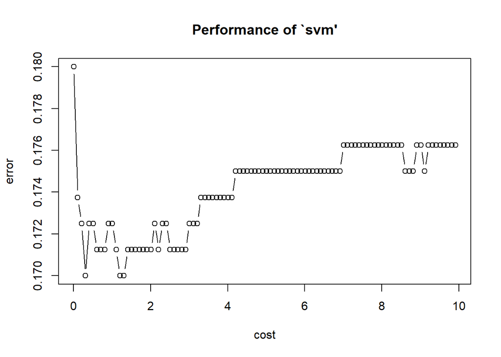

```r
plot(tune_lnr)
```

```r
pred_lnr1 <- predict( tune_lnr$best.model, juice_train)
pred_lnr2 <- predict( tune_lnr$best.model, juice_test)

confmatrix_lnr1 <- table(Actual = juice_train$Purchase, Predicted = pred_lnr1)
confmatrix_lnr1
```

```
##       Predicted
## Actual  CH  MM
##     CH 429  59
##     MM  76 236
```

```r
confmatrix_lnr2 <- table(Actual = juice_test$Purchase, Predicted = pred_lnr2)
confmatrix_lnr2
```

```
##       Predicted
## Actual  CH  MM
##     CH 109  13
##     MM  20  58
```

Train Accuracy Score - 0.83125

Test Accuracy Score - 0.835

Train Error Rate - 0.16875

Test Error Rate - 0.165

## RBF Model

```r
set.seed(123)
svm_rbf <- svm(Purchase~., data=juice_train, cost=0.01)

summary(svm_rbf)
```

```
##
## Call:
## svm(formula = Purchase ~ ., data = juice_train, cost = 0.01)
##
##
## Parameters:
##    SVM-Type:  C-classification
##  SVM-Kernel:  radial
##        cost:  0.01
##
## Number of Support Vectors:  627
##
##  ( 312 315 )
##
##
## Number of Classes:  2
##
## Levels:
##  CH MM
```

```r
pred_rbf1 <- predict( svm_rbf, juice_train)
pred_rbf2 <- predict( svm_rbf, juice_test)

confmatrix_rbf1 <- table(Actual = juice_train$Purchase, Predicted = pred_rbf1)
confmatrix_rbf1
```

```
##       Predicted
## Actual  CH  MM
##     CH 488   0
##     MM 312   0
```

```r
confmatrix_rbf2 <- table(Actual = juice_test$Purchase, Predicted = pred_rbf2)
confmatrix_rbf2
```

```
##       Predicted
## Actual  CH  MM
##     CH 122   0
##     MM  78   0
```

Train Accuracy Score - 0.61

Test Accuracy Score - 0.61

Train Error Rate - 0.39

Test Error Rate - 0.39

## Tuned RBF Model

```r
set.seed(123)
tune_rbf <- tune(svm, Purchase~., data = juice_train,
                 ranges = list(cost=cost_arr))

summary(tune_rbf)
```

```
##
## Parameter tuning of 'svm':
##
## - sampling method: 10-fold cross validation
##
## - best parameters:
##  cost
##  0.31
##
## - best performance: 0.1825
##
## - Detailed performance results:
##     cost   error dispersion
## 1   0.01 0.39000 0.06422616
## 2   0.11 0.19250 0.03782269
```

[output cut: 98 more lines]

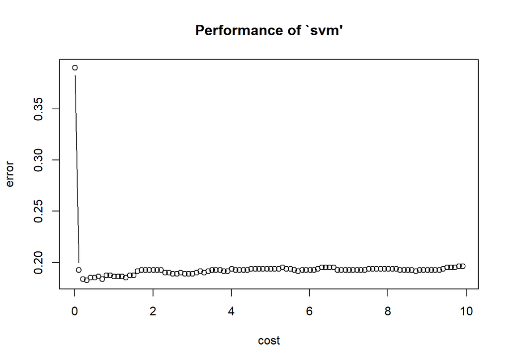

```r
plot(tune_rbf)
```

```r
pred_rbf1 <- predict( tune_rbf$best.model, juice_train)
pred_rbf2 <- predict( tune_rbf$best.model, juice_test)

confmatrix_rbf1 <- table(Actual = juice_train$Purchase, Predicted = pred_rbf1)
confmatrix_rbf1
```

```
##       Predicted
## Actual  CH  MM
##     CH 440  48
##     MM  80 232
```

```r
confmatrix_rbf2 <- table(Actual = juice_test$Purchase, Predicted = pred_rbf2)
confmatrix_rbf2
```

```
##       Predicted
## Actual  CH  MM
##     CH 113   9
##     MM  24  54
```

Train Accuracy Score - 0.84

Test Accuracy Score - 0.835

Train Error Rate - 0.16

Test Error Rate - 0.165

## Polynomial Model

```r
set.seed(123)
svm_poly <- svm(Purchase~., data=juice_train, kernel ="poly", cost=0.01, degree=2)

summary(svm_poly)
```

```
##
## Call:
## svm(formula = Purchase ~ ., data = juice_train, kernel = "poly",
##     cost = 0.01, degree = 2)
##
##
## Parameters:
##    SVM-Type:  C-classification
##  SVM-Kernel:  polynomial
##        cost:  0.01
##      degree:  2
##      coef.0:  0
##
## Number of Support Vectors:  627
##
##  ( 312 315 )
##
##
## Number of Classes:  2
##
## Levels:
##  CH MM
```

```r
pred_poly1 <- predict(svm_poly, juice_train)
pred_poly2 <- predict(svm_poly, juice_test)

confmatrix_poly1 <- table(Actual = juice_train$Purchase, Predicted = pred_poly1)
confmatrix_poly1
```

```
##       Predicted
## Actual  CH  MM
##     CH 481   7
##     MM 292  20
```

```r
confmatrix_poly2 <- table(Actual = juice_test$Purchase, Predicted = pred_poly2)
confmatrix_poly2
```

```
##       Predicted
## Actual  CH  MM
##     CH 122   0
##     MM  71   7
```

Train Accuracy Score - 0.62625

Test Accuracy Score - 0.645

Train Error Rate - 0.37375

Test Error Rate - 0.355

```r
set.seed(123)
tune_poly <- tune(svm, Purchase~., data = juice_train, kernel="poly", degree=2,
                 ranges = list(cost=cost_arr))

summary(tune_poly)
```

```
##
## Parameter tuning of 'svm':
##
## - sampling method: 10-fold cross validation
##
## - best parameters:
##  cost
##  9.61
##
## - best performance: 0.22875
##
## - Detailed performance results:
##     cost   error dispersion
## 1   0.01 0.37875 0.07193989
## 2   0.11 0.35750 0.05533986
```

[output cut: 98 more lines]

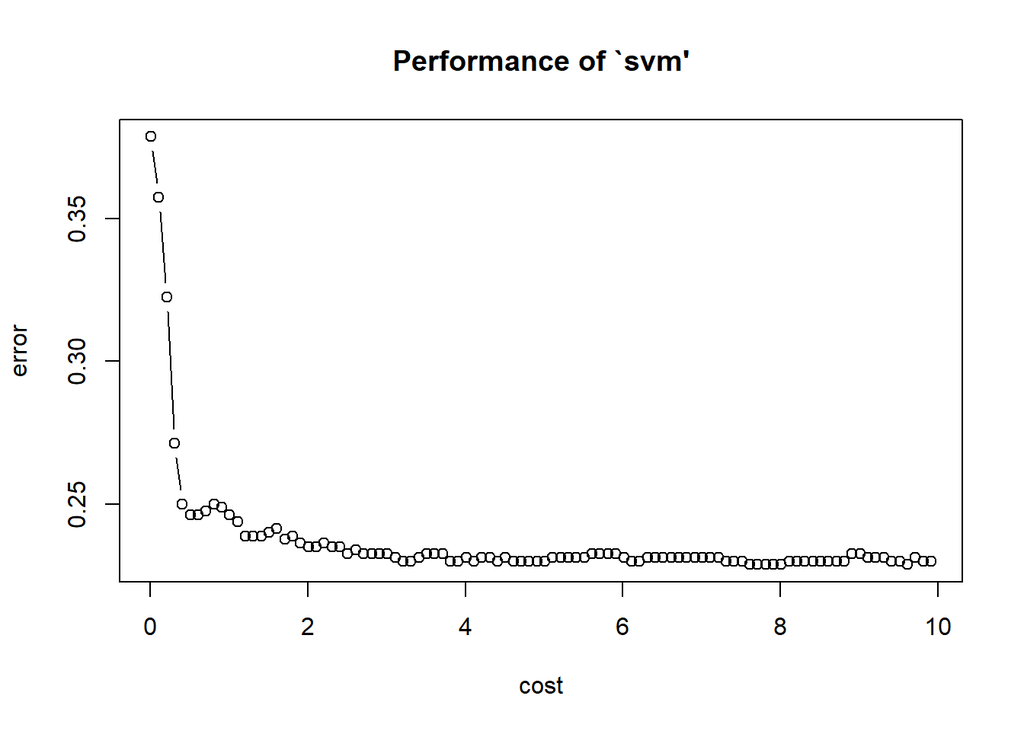

```r
plot(tune_poly)
```

```r
pred_poly1 <- predict( tune_poly$best.model, juice_train)
pred_poly2 <- predict( tune_poly$best.model, juice_test)

confmatrix_poly1 <- table(Actual = juice_train$Purchase, Predicted = pred_poly1)
confmatrix_poly1
```

```
##       Predicted
## Actual  CH  MM
##     CH 437  51
##     MM 118 194
```

```r
confmatrix_poly2 <- table(Actual = juice_test$Purchase, Predicted = pred_poly2)
confmatrix_poly2
```

```
##       Predicted
## Actual  CH  MM
##     CH 104  18
##     MM  34  44
```

Train Accuracy Score - 0.78875

Test Accuracy Score - 0.74

Train Error Rate - 0.21125

Test Error Rate - 0.26

## Conclusion

After comparing the Train and Test Scores for all the models:

Basic Models

SVM with Linear Kernel is the best in case of Basic Models with the least Error scores for both Train and Test datasets.

Tuned Models

For both RBF and Linear Kernels, the cost parameter for the best model is 0.31 and the scores are almost equal. For Polynomial, the cost parameter is 9.61 but the model isn’t as good.